# Regression and model validation

*Describe the work you have done this week and summarize your learning.*

- Describe your work and results clearly.
- Assume the reader has an introductory course level understanding of writing and reading R code as well as statistical methods
- Assume the reader has no previous knowledge of your data or the more advanced methods you are using
- First, I was reading dataset into R:

```r
students2014 <- read.csv("learning2014.csv", header = T , sep = "," )
```

The dataset is based on the students’ survey. The questions are grouped in 3 groups by questions’ topics:

1. questions related to deep learning
2. questions related to surface learning
3. questions related to strategic learning

In addition, there are factor variables as age, gender. Also, “points” (exam points) and “attitude” (global attitude towards statistics) variables.

Combinational variables (deep, surface and strategic learning questions) are scaled back to the original scales by taking mean. Overall we have 166 observations witj 7 variables.

- Next I am showing graphical overwiev of the data and summaries of the variables:

```r
summary(students2014$deep)
```

```
##    Min. 1st Qu.  Median    Mean 3rd Qu.    Max.
##   1.583   3.333   3.667   3.680   4.083   4.917
```

```r
summary(students2014$stra)
```

```
##    Min. 1st Qu.  Median    Mean 3rd Qu.    Max.
##   1.250   2.625   3.188   3.121   3.625   5.000
```

```r
summary(students2014$surf)
```

```
##    Min. 1st Qu.  Median    Mean 3rd Qu.    Max.
##   1.583   2.417   2.833   2.787   3.167   4.333
```

```r
summary(students2014$Points)
```

```
##    Min. 1st Qu.  Median    Mean 3rd Qu.    Max.
##    7.00   19.00   23.00   22.72   27.75   33.00
```

```r
summary(students2014$gender)
```

```
##   F   M
## 110  56
```

We can see that the major part of the students were women.

```r
summary(students2014$Age)
```

```
##    Min. 1st Qu.  Median    Mean 3rd Qu.    Max.
##   17.00   21.00   22.00   25.51   27.00   55.00
```

The maximun age was 55, the minimum 17, the median 22 and the mean 25.51 years.

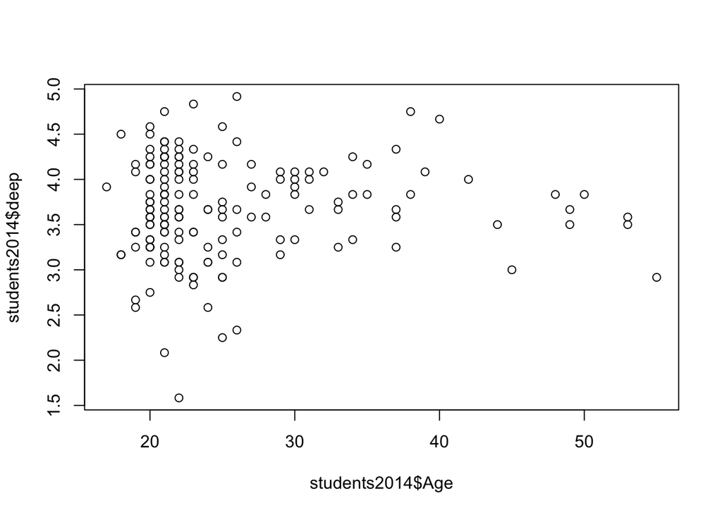

```r
plot(students2014$Age,students2014$deep)
```

The mean of the deep group questions was 3.68. From the deep questions we can see the students’ motivation of understanding “deep” meaning of their studies. For example, “D03: I usually set out to understand for myself the meaning of what we have to learn.” So we can see that the motivation for deep understanding is average.

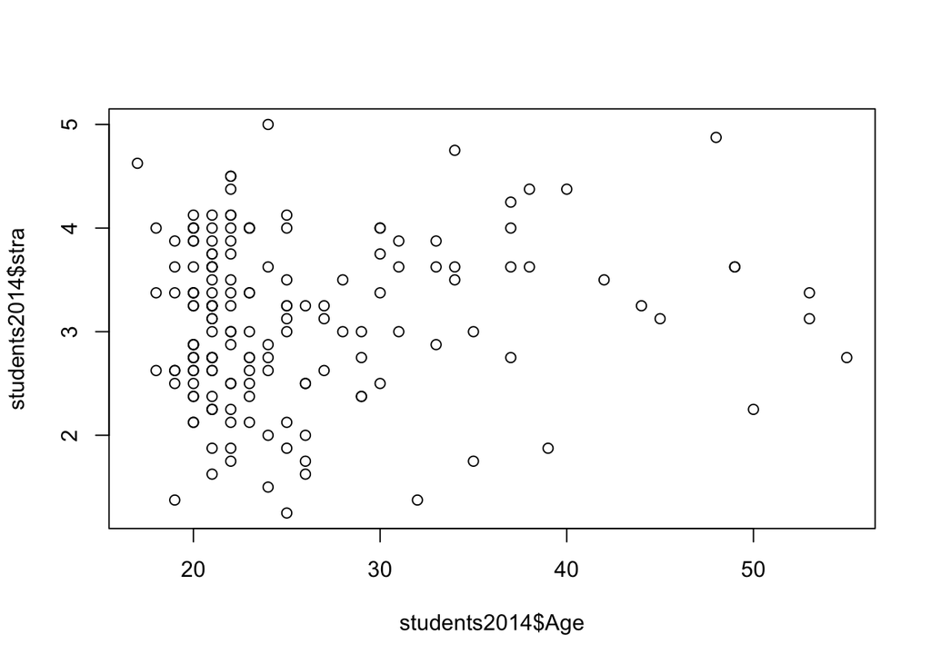

```r
plot(students2014$Age, students2014$stra)
```

Strategic questions were related to strategic studying motivation. For an example, “ST09: I think I’m quite systematic and organised when it comes to revising for exams.” The mean of the strategic questions is 3.121. It is a bit lower than of deep questions group but still average.

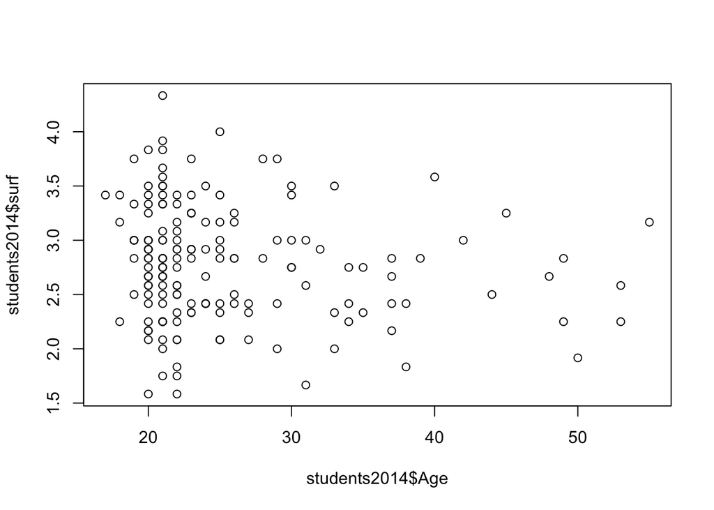

```r
plot(students2014$Age, students2014$surf)
```

The questions related to surface learning group has mean of 2.787 but the direction of scale is opposite, it has negative direction. An exaple of a question “SU10: There’s not much of the work here that I find interesting or relevant.”. So the low mean is actually good thing and students were interested in the course and it was helpful.

From the 3 plots above we can see that the major part of the students were from the age group 20-30.

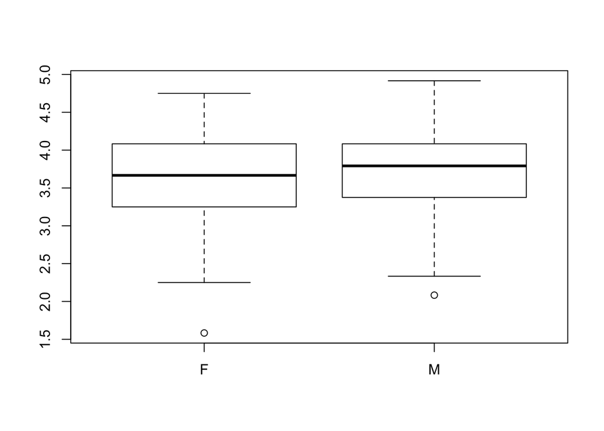

```r
plot(students2014$gender,students2014$deep)
```

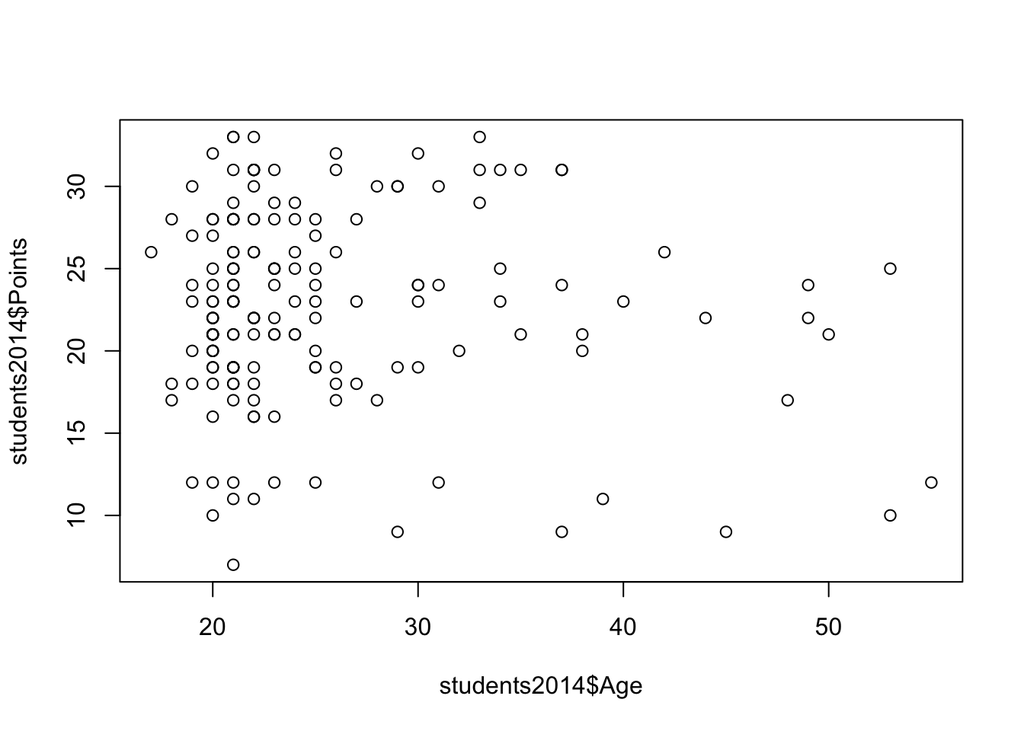

```r
plot(students2014$Age, students2014$Points)
```

- I have chosen as as a explanatory variable “Attitude”-variable with exam points as the target (dependent) variable.

I am using the package “ggplot2”:

```r
library(ggplot2)
```

Initializing plot with data and aesthetic mapping:

```r
p1 <- ggplot(students2014, aes(x = Attitude, y = Points, col = gender))
```

Defining the visualization type (points):

```r
p2 <- p1 + geom_point()
```

Drawing the plot:

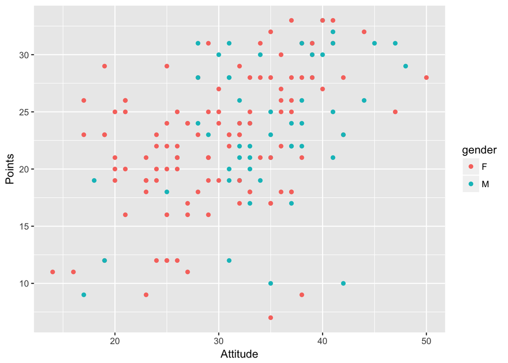

```r
p2
```

Adding a regression line:

```r
p3 <- p2 + geom_smooth(method = "lm")
```

Adding a main title and drawing the plot:

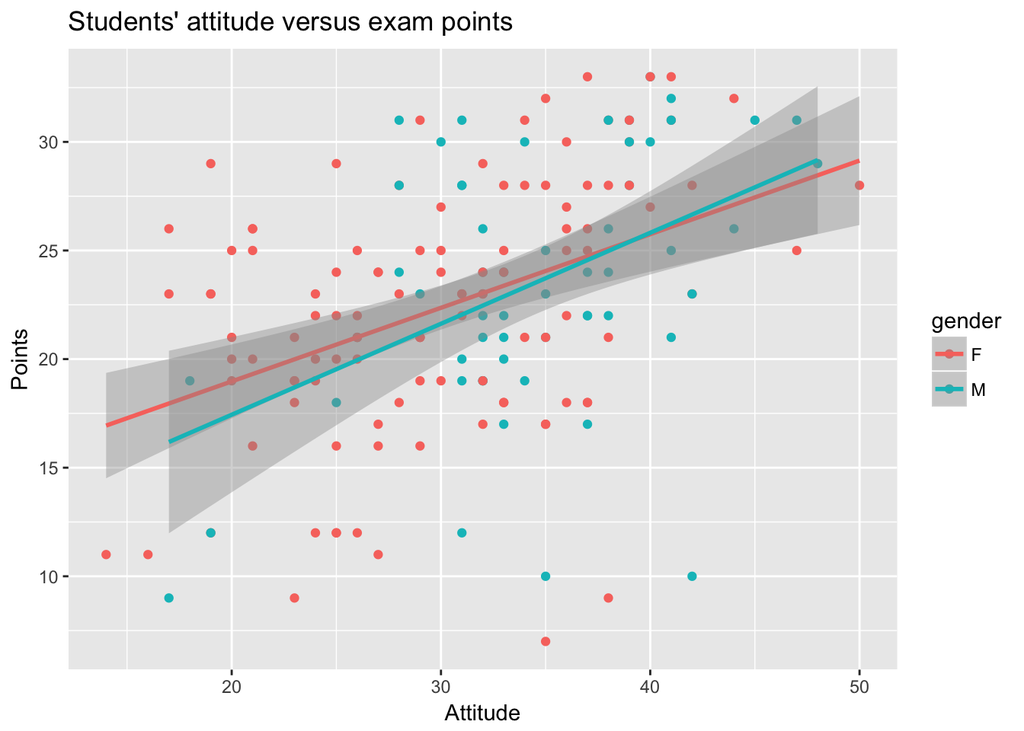

```r
p4 <- p3 + ggtitle("Students' attitude versus exam points")
p4
```

```r
ggsave("Students_attitude_VS_exam_points.png", width = 5, height = 5)
```

Regression analysis:

```r
model <- lm(Points ~ Attitude + stra + surf, data = students2014)

summary(model)
```

```
##
## Call:
## lm(formula = Points ~ Attitude + stra + surf, data = students2014)
##
## Residuals:
##      Min       1Q   Median       3Q      Max
## -17.1550  -3.4346   0.5156   3.6401  10.8952
##
## Coefficients:
##             Estimate Std. Error t value Pr(>|t|)
## (Intercept) 11.01711    3.68375   2.991  0.00322 **
## Attitude     0.33952    0.05741   5.913 1.93e-08 ***
## stra         0.85313    0.54159   1.575  0.11716
## surf        -0.58607    0.80138  -0.731  0.46563
## ---
## Signif. codes:  0 '***' 0.001 '**' 0.01 '*' 0.05 '.' 0.1 ' ' 1
##
## Residual standard error: 5.296 on 162 degrees of freedom
## Multiple R-squared:  0.2074, Adjusted R-squared:  0.1927
## F-statistic: 14.13 on 3 and 162 DF,  p-value: 3.156e-08
```

From the plot we can see correlation only between “attitude” and “exam points”. From regression analysis we can see that: - There is some correlation between attitude and exam points. P-value is very low, even though the estimate for attitude is just 0.35. - The correlation between strategic questions and points is weaker, p-value is higher. - The correlation between “surface questions” and “exam points” is negative and the p-value is high and not significantly different from zero. –> The most significant is “Attitude”.

Let remove “surf” variable:

```r
model2 <- lm(Points ~ Attitude + stra, data = students2014)
summary(model2)
```

```
##
## Call:
## lm(formula = Points ~ Attitude + stra, data = students2014)
##
## Residuals:
##      Min       1Q   Median       3Q      Max
## -17.6436  -3.3113   0.5575   3.7928  10.9295
##
## Coefficients:
##             Estimate Std. Error t value Pr(>|t|)
## (Intercept)  8.97290    2.39591   3.745  0.00025 ***
## Attitude     0.34658    0.05652   6.132 6.31e-09 ***
## stra         0.91365    0.53447   1.709  0.08927 .
## ---
## Signif. codes:  0 '***' 0.001 '**' 0.01 '*' 0.05 '.' 0.1 ' ' 1
##
## Residual standard error: 5.289 on 163 degrees of freedom
## Multiple R-squared:  0.2048, Adjusted R-squared:  0.1951
## F-statistic: 20.99 on 2 and 163 DF,  p-value: 7.734e-09
```

Now the p-value of “stra” improved a little bit. I add the “Age”-variable to compare the results.

```r
model3 <- lm(Points ~ Attitude + stra + Age, data = students2014)
summary(model3)
```

```
##
## Call:
## lm(formula = Points ~ Attitude + stra + Age, data = students2014)
##
## Residuals:
##      Min       1Q   Median       3Q      Max
## -18.1149  -3.2003   0.3303   3.4129  10.7599
##
## Coefficients:
##             Estimate Std. Error t value Pr(>|t|)
## (Intercept) 10.89543    2.64834   4.114 6.17e-05 ***
## Attitude     0.34808    0.05622   6.191 4.72e-09 ***
## stra         1.00371    0.53434   1.878   0.0621 .
## Age         -0.08822    0.05302  -1.664   0.0981 .
## ---
## Signif. codes:  0 '***' 0.001 '**' 0.01 '*' 0.05 '.' 0.1 ' ' 1
##
## Residual standard error: 5.26 on 162 degrees of freedom
## Multiple R-squared:  0.2182, Adjusted R-squared:  0.2037
## F-statistic: 15.07 on 3 and 162 DF,  p-value: 1.07e-08
```

We can see that there is a relation between “exam points” and “Age” variables even if not very significant. The most explanatory variable is still “Attitude”.

Now we can make Residual vs Fitted values, Normal QQ-plot and Residual vs Leverage analysis.

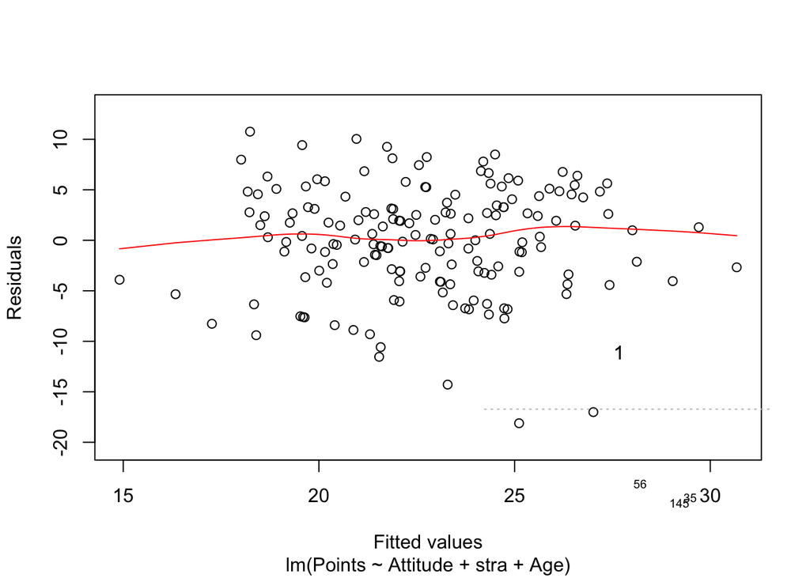

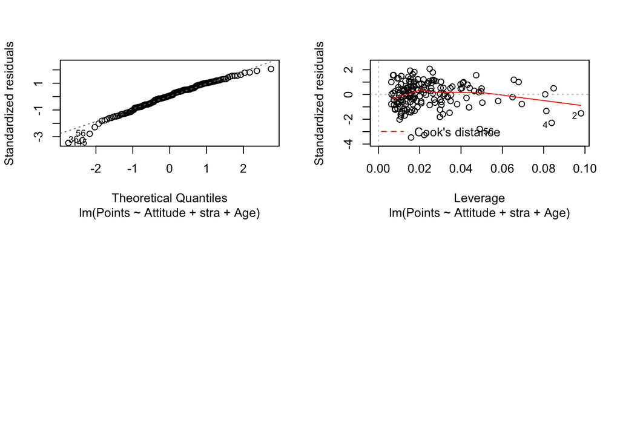

```r
plot(model3,which = c(1,2,5),par(mfrow = c(2,2)))
```